# Part 1 - Explore

## 6 - Statistical Transformation

### 6.1 - Notes

Some plots automatically calculate new values for your plots. An example is the `diamonds` data set where there is no count variable. When making a bar plot a count is calculated:

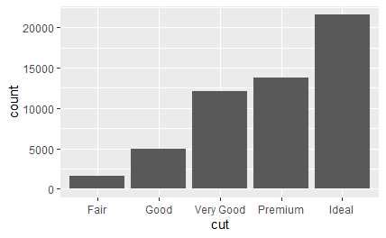

When doing this, the plots bins the data, and counts the number/count that falls within each bin. This occurs for bar charts, histograms, and frequency polygons.

Other automatically calculated stuff can include smoothness model, and summary from boxplots.

The algorithms used for these transformations are called a `stat` (short for statistical transformation).

You can see/view which `stat` that `geoms` uses by using `?`.

```r
?geom_bar
```

Here it says:

> geom_bar() uses stat_count() by default.

You can sometimes use `stats` interchangeability with `geoms`. The previous graph can also be made like this.

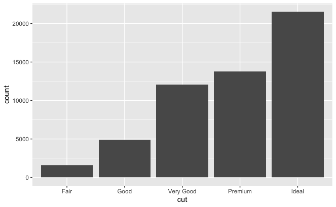

```r
ggplot(data = diamonds) +
  stat_count(mapping = aes(x = cut))
```

There are three reasons you might choose to use `stats` over `geoms`.

1. Override default stat (i.e. change from count to identity)

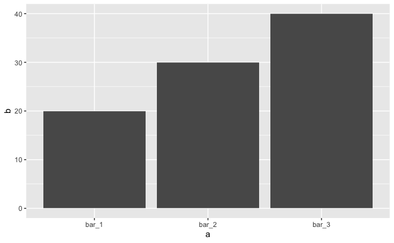

```r
demo <- tribble (
  ~a,       ~b,
  "bar_1",  20,
  "bar_2",  30,
  "bar_3",  40,
)

ggplot(data = demo) +
  geom_bar(mapping = aes(x = a, y = b), stat = "identity")
```

2. Override default mapping. You might want to show something other than a normal Y column, for example proportion.

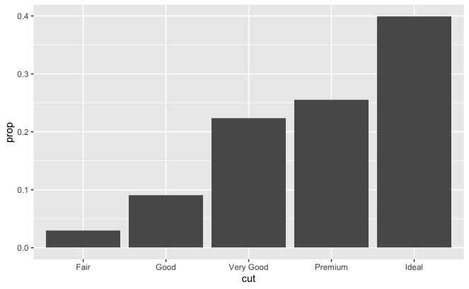

```r
ggplot(data = diamonds) +
  geom_bar(mapping = aes(x = cut, y = ..prop.., group = 1))
```

3. You can add more summary data to the plot.

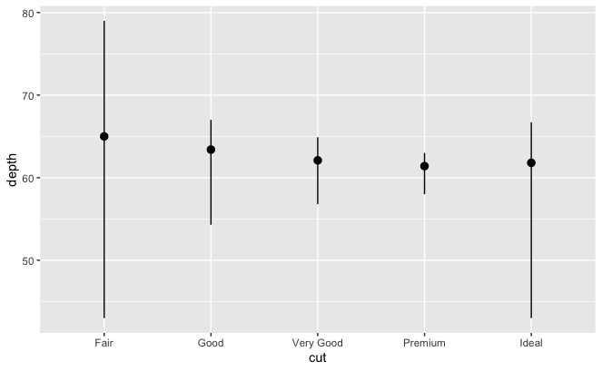

```r
ggplot(data = diamonds) +
  stat_summary(mapping = aes(x = cut, y = depth), fun.min = min, fun.max = max, fun = median)
```

### 6.2 - Exercises

#### **Question 1 - What is the default geom associated with stat_summary()? How could you rewrite the previous plat using geom instead of stat?**

I will first look at the documentation for stat_summary()

```r
?stat_summary
```

Here it says we can use geom_pointrange. Lets try that.

```r
ggplot(data = diamonds) +
  geom_pointrange(
    mapping = aes(x = cut, y = depth),
    stat = "summary",
    fun.ymin = min,
    fun.ymax = max,
    fun.y = median)
```

**2 - What does geom_col() do? How is it different to geom_bar()?**

Lets find out.

```r
?geom_col()
```

Geom_bar makes the height of the bar proportional to number of cases in each group. If you want them to be reperesent values in the acctual data, geom_col() does this. I.e. geom_bar() uses stat_count, while geom_col() uses stat_identity.

**3 - Most geoms and stats come in pairs that are almost always used in concert. What does these pairs have in common?**

We should read documentation.

```r
?stat_bin()
```

They often have similar names. They often do the same thing. Also, they use each other for the same thing. I.e. geom uses a stat, and a stat shows it using a geom. Dont really know why there are two types. Maybe to make it easier in edgecases.

**4 - What variables does stat_smooth() compute? What parameter controls its behavior?**

```r
?stat_smooth()
```

Stat smooth compute the SE using the predictdf function (usually). Also, y, ymin, and yma. The parameters that controls its behavior is method, formula, and na.rm.

**5 - What is the problems with these graphs?**

```r
ggplot(data = diamonds) +
  geom_bar(mapping = aes(x = cut, y = ..prop..))

ggplot(data = diamonds) +
  geom_bar(mapping = aes(x = cut, fill = color, y = ..prop.., group = 1))
```

The problem here is that they are all one. We need to set group to one. Prop is a groupwise proportion, and as such we need to have a group.

# 7 - Position Adjustments

## 7.1 - Notes

You can fill bar charts using the color aesthetic.

```r
ggplot(data = diamonds) +
  geom_bar(mapping = aes(x = cut, color = cut))
```

Or better yet

```r
ggplot(data = diamonds) +
  geom_bar(mapping = aes(x = cut, fill = cut))
```

You can also fill stuff in different variables like this:

```r
ggplot(data = diamonds) +
  geom_bar(mapping = aes(x = cut, fill = clarity))
```

You can use position function to set how the different colors should be positioned. In the below example they are positioned based on their identity.

```r
ggplot(data = diamonds, mapping = aes(x = cut, fill = clarity)) +
  geom_bar(alpha = 1/5, position = "identity")
```

Alpha stand for ocupizaty.

You can also set a fill position

```r
ggplot(data = diamonds, mapping = aes(x = cut, fill = clarity)) +
  geom_bar(position = "fill")
```

Here we fill the entire Y axis. This makes it easier to compare propoprtions of clarity inside the same sample.

```r
ggplot(data = diamonds, mapping = aes(x = cut, fill = clarity)) +
  geom_bar(alpha = 1/5, position = "dodge")
```

There are also more types of adjustements that are more useful for other types of geoms. For example, if points overlap (called overplotting) you can avoid this by using the jitter function. This function adds some random noise to each variable so that you are able to see them all.

This would in theory make your graph less accurate at small scales, however, more accurate at large scales.

YOu can also use geom_jitter() to do this quickly.

Like this:

```r
ggplot(data = mpg) +
  geom_point(mapping = aes(x = displ, y = hwy), position = "jitter")
```

## 7.1 - Exercises

**1 - What is the problem with this plot and how can you fix it?**

```r
ggplot(data = mpg, mapping = aes(x = cty, y = hwy)) +
  geom_point()
```

The problem is that stuff overlap, as there are only that many ctys and hwy combinations. This can be fixed by adding jitter.

```r
ggplot(data = mpg, mapping = aes(x = cty, y = hwy)) +
  geom_jitter()
```

**2 - What parameters to geom_citter() control the amount of jittering?**

We will look at the documentations.

```r
?geom_jitter
```

Height and width is added to jitter. By default this is 40% of the resolutinon of the data.

**3 - Compre and contrast geom_jitter with geom_count**

Lets make a geom count graph

```r
ggplot(data = mpg, mapping = aes(x = cty, y = hwy)) +
  geom_count()
```

Geom count adds the count to the graph, increasing the size (or other variables) dependent of how many items are in that exact positon.

**4 - What is the default position adjustment for geom_boxplot? Create a visulization of mpg do demonstrate this**

Lets first look at the documentation.

```r
?geom_boxplot
```

The default position adjustement is “dodge2”, which is.

```r
ggplot(data = mpg, mapping = aes(x = cty, y = hwy)) +
  geom_boxplot(position = "dodge2")
```

# 8 - Coordinate systems

## 8.1 - Notes

Coordinate systems are the most complicated part of ggplot2. The default coordinate system is something called cartesian coordinate. This is where x and y is independent. There is also a bunh of other stuff that is usefull

- Coord_flip = Switches x and y axis.

```r
ggplot(data = mpg, mapping = aes(x = class, y = hwy)) +
  geom_boxplot() +
  coord_flip()
```

```r
install.packages("maps")
nz <- map_data("nz")

ggplot(data = nz, aes(long, lat, group = group)) +
  geom_polygon(fill = "white", color = "black")
  coord_map()
```

- Coords_polar = makes polar coordinate.

```r
bar <- ggplot(data = diamonds) +
  geom_bar(mapping = aes(x = cut, fill = cut), show.legend = FALSE, width = 1) +
  theme(aspect.ratio = 1) +
  labs(x = NULL, y = NULL)

bar + coord_flip()
bar + coord_polar()
```

## 8.2 - Exercises

**1 - Turn a stacked bar chart into pie chart using coord_polar**

```r
bar <- ggplot(data = diamonds) +
  geom_bar(mapping = aes(x = cut, fill = cut), show.legend = FALSE, width = 1) +
  theme(aspect.ratio = 1) +
  labs(x = NULL, y = NULL)

bar + coord_flip()
bar + coord_polar()
```

**2 - What does labs() do?**

Read the documentation.

```r
?labs
```

Labs modifies axis legend and plot labels.

**3 - What’s the difference between coord_quickmap() and coord_map()?**

```r
?coord_quickmap
?coord_map
```

Quickmap is a approximation that does preserve straight lines.

```r
install.packages("maps")
nz <- map_data("nz")

ggplot(data = nz, aes(long, lat, group = group)) +
  geom_polygon(fill = "white", color = "black") +
  coord_map()
```

**4 - What does the following plot tell you? Why is coord_fixed important? And what does geom_abline() do?**

Plot:

```r
ggplot(data = mpg, mapping = aes(x = cty, y = hwy)) +
  geom_point() +
  geom_abline() +
  coord_fixed()
```

This plot tells us that there is a linear relationship between cty and hwy.

```r
ggplot(data = mpg, mapping = aes(x = cty, y = hwy)) +
  geom_point() +
  geom_abline()
```

Without cord fixed, the x and y axis is no longer equal, making it somehwat more difficult to see. I.e. one unit on the x axis is one unit on the y axis when using coord_fixed().

```r
ggplot(data = mpg, mapping = aes(x = cty, y = hwy)) +
  geom_point() +
  coord_fixed()
```

Geom_abline creates a refference line line.

# 9 - The layered grammer of graphics

## 9.1 - Notes

ggplot template:

```r
ggplot(date = <DATA>) +
  <GEOM>(mapping = aes(<MAPPINGS>), stat = <STAT>, position = <POSITION>) +
  <CORDINATE_FUNCTION> +
  <FACET_FUNCTION>
```

This template can build all types of graphs!